# FLife: Operating Model Conditioning

Turbot

L Kell & A Tidd

01 November, 2018

## Life history parameters

```
[1] 1
[1] "length" "params"
[1] 2
```

Life history parameters from Fish Base for the Von Bertalanffy growth model were $L_{\infty}$ (58.7), $k$ (0.286), and $t_0$ (-0.416), for the length/weight relationship $W=aL^b$ were $a$ (0.0204) and $b$ (2.93), and age at maturity ($a_{50}$) was (4.41).

The fishery was assumed to only catch mature fish and so selection pattern is modelled by a double normal equivalent to the maturity ogive, parameters were $a_1$, $s_l$ and $s_r$ were (5.41, 1, 5000) respectively.

The stock recruitment relationship is assummed to be of a Beverton and Holt functional form with a steepness and virgin biomass of 0.8 and 1000 units respectively.

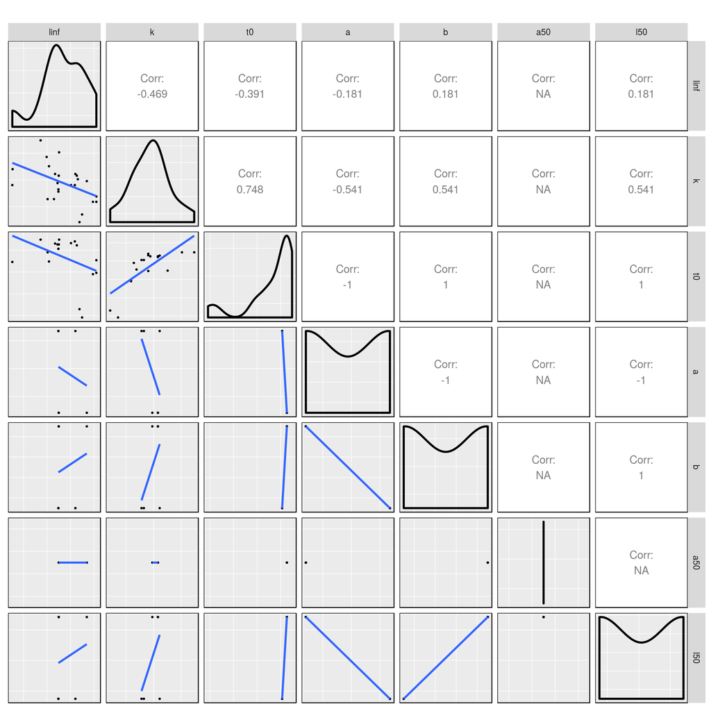

**Figure 1** Pairwise scatter plots of life history parameters.

## Equilibrium dynamics

The parameters are then used by `lhEql` to simulate the equilibrium dynamics by combining the spawner/yield per recruit relationships with a stock recruiment relationship.

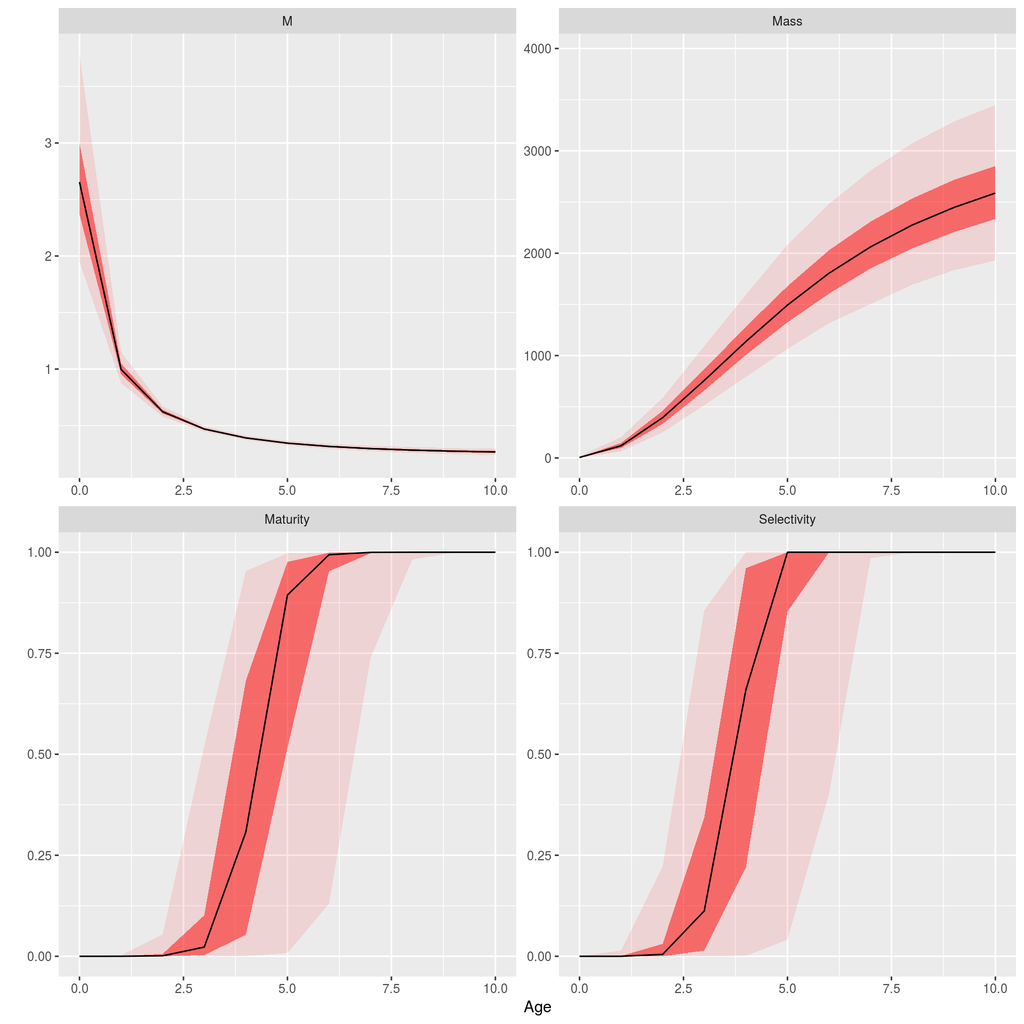

**Figure 2** Vectors.

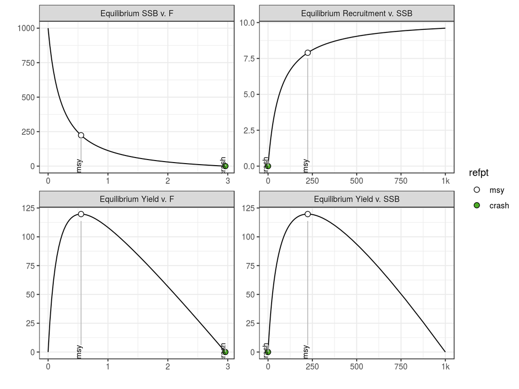

**Figure 3** Example equilibrum Curve.

## Population dynamics

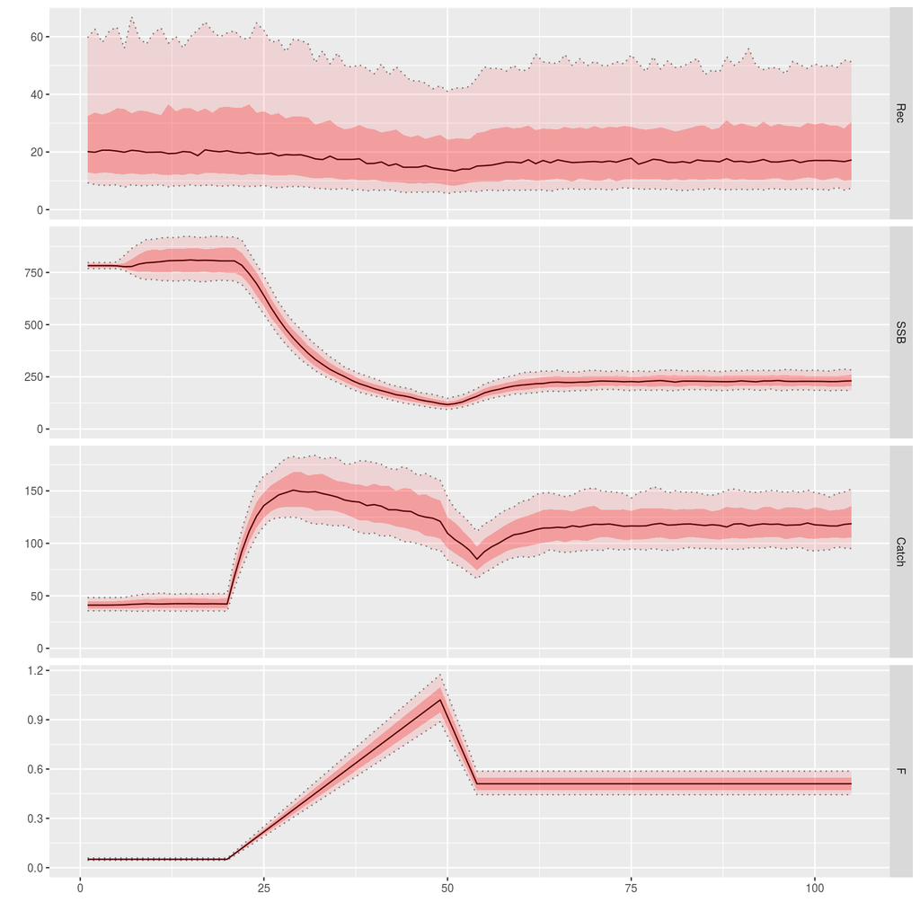

**Figure 4** Time series.

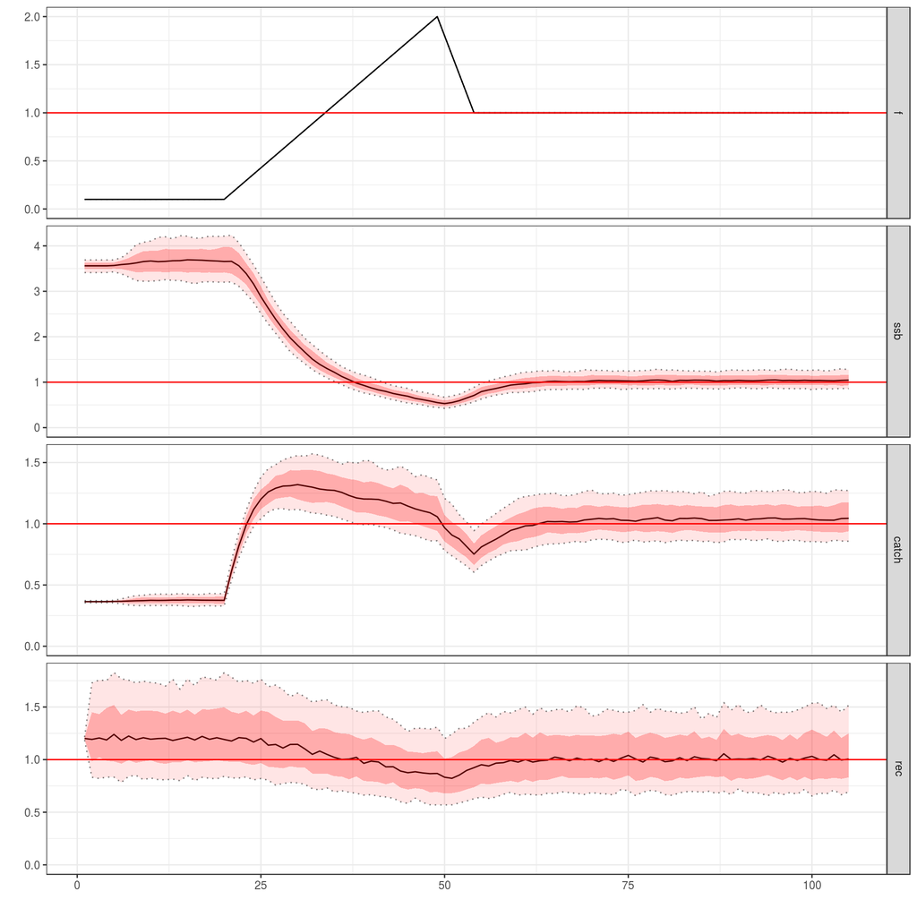

**Figure 5** Time series relative to MSY benchmarks.

## Software Versions

- R version 3.4.4 (2018-03-15)
- FLCore: 2.6.9.9009
- FLBRP: 2.5.3.9001
- FLasher: 0.5.0.9001
- FLife: 3.2.1.9001
- ggplotFL: 2.6.4.9002
- **Compiled**: Thu Nov 1 13:25:31 2018

## Author information

**Laurence Kell**. laurie@seaplusplus.es

## Acknowledgements

This vignette and many of the methods documented in it were developed under the MyDas project funded by the Irish exchequer and EMFF 2014-2020. The overall aim of MyDas is to develop and test a range of assessment models and methods to establish Maximum Sustainable Yield (MSY) reference points (or proxy MSY reference points) across the spectrum of data-limited stocks.